# DATA607-Week05-Project02

Pavan Akula

March 7, 2017

The goal of this assignment is to prepare different datasets<sup>1</sup> (databases) for downstream analysis work. Following are the 3 datasets that will be used for this project. Dataset sources was identified by

**1. World Development Indicators (WDI) - *Kyle Gilde***

**2. IRS’s Statistics of Income (SOI) - *Pavan Akula***

**3. United States Census Bureau - Imports of Crude Oil - *Nnaemezue Obi-eyisi***

Libraries used for the project

```r
#install.packages("xlsx")
library(xlsx)     # used for loading files with extension xlsx and xls
library(utils)    # loading csv files
library(tidyr)    # formating data
library(dplyr)    # subseting, changing data layout
library(stringr)  # regular expression and data manupilation
library(ggplot2)  # graphs generation
library(knitr)    # report display, table format
library(readr)    # reading text files data
```

### 1. World Development Indicators (WDI)

The World Bank maintains [*World Development Indicators (WDI) database.*](http://data.worldbank.org/data-catalog/world-development-indicators) Collection of development indicators are compiled from officially-recognized international sources by World Bank. It presents the most current and accurate global development data available, and includes national, regional and global estimates. Database contains various indicator topics including Agriculture & Rural Development, Aid Effectiveness, Climate Change, Economy & Growth, Education, Energy & Mining, Environment, External Debt, Financial Sector, Gender, Health, Infrastructure, Labor & Social Protection, Poverty, Private Sector, Public Sector, Science & Technology, Social Development, Trade and Urban Development.

Data is classified by World Bank into economies, regions, income groups and lending groups. Database has data from year 1960 to current. Update frequency of the database is quarterly. Complete database and data dictionary is available in Zip file format at World Bank website http://data.worldbank.org/data-catalog/world-development-indicators.

More information about data classification and collection can be found at

1. Country classification: https://datahelpdesk.worldbank.org/knowledgebase/articles/378834-how-does-the-world-bank-classify-countries
2. Data Compilation Methodology: https://datahelpdesk.worldbank.org/knowledgebase/articles/201203
3. Country and Lending Groups: https://datahelpdesk.worldbank.org/knowledgebase/articles/906519-world-bank-country-and-lending-groups

Using WDI database, development indicators for last 10 years that fall under *Financial Sector: Access* topic will be analysed for G20 nations. To be more specific only one indicator *Average transaction cost of sending and receving remittances from or to a specific country* will be analysis.

```r
# Load World Indicators from WDI_Series.csv
# This file contains information about each indicator
# There are about 17 indicators that fall under Financial Sector: Access
wd <- getwd()
wdi.indicator.data <- read.csv(paste(wd , "\\WDI_Series.csv", sep = ""), stringsAsFactors = FALSE, header = TRUE)
wdi.indicator.finsec.access <- wdi.indicator.data %>%
  filter(Topic == "Financial Sector: Access") %>%
  select(Indicator.Name)

# G20 nations
#nations <- c("Argentina","Australia","Brazil","Canada","China","France","Germany","India","Indonesia","Italy","Japan","Mexico","Russian Federation","Saudi Arabia","South Africa","South Korea","Turkey","United Kingdom","United States","Austria","Belgium","Bulgaria","Croatia","Cyprus","Czech Republic","Denmark","Estonia","Finland","Greece","Hungary","Ireland","Latvia","Lithuania","Luxembourg","Malta","Netherlands","Poland","Portugal","Romania","Slovak Republic","Slovenia","Spain","Sweden")

nations <- c("Argentina","Australia","Brazil","Canada","China","France","Germany","India","Indonesia","Italy","Japan","Mexico","Russia","Saudi Arabia","South Africa","South Korea","Turkey","United Kingdom","United States","European Union")

g20.nations <- data.frame(nations, stringsAsFactors = FALSE)

# Assign unique id's to nations
g20.nations <- g20.nations %>%
  mutate(id = row_number())

# Load World Development Indicators (WDI) database
# Database has 383328 observations with 61 variables
wdi.raw.data <- read.csv(paste(wd, "\\WDI_Data.csv", sep = ""), stringsAsFactors = FALSE, header = TRUE)

#str(wdi.raw.data)
# Format data, some rows have [ts] and [w2] at the end of indicator description
wdi.raw.data$Indicator.Name <- gsub("\\[ts\\]", "" ,wdi.raw.data$Indicator.Name)
wdi.raw.data$Indicator.Name <- gsub("\\[w2\\]", "" ,wdi.raw.data$Indicator.Name)
wdi.raw.data$Indicator.Name <- str_trim(wdi.raw.data$Indicator.Name)
wdi.raw.data$Country.Name <- str_replace(wdi.raw.data$Country.Name, "Russian Federation", "Russia")
wdi.raw.data$Country.Name <- str_replace(wdi.raw.data$Country.Name, "Korea, Rep\\.", "South Korea")

# Filter data for last 10 years excluding 2016
# Get data only for G20 nations
wdi.g20.nations.raw <- wdi.raw.data %>%
  inner_join(wdi.indicator.finsec.access, by = "Indicator.Name") %>%
  inner_join(g20.nations, by = c("Country.Name" = "nations")) %>%
  select (id, Country.Name, Country.Code, Indicator.Name, X2006:X2015)

#unique(wdi.g20.nations.raw$Indicator.Name)
#unique(wdi.g20.nations.raw$Country.Name)
# Tidy the data set

wdi.g20.nations.tidy.data <- wdi.g20.nations.raw %>%
  gather(Year, value = Measure, X2006:X2015, na.rm = FALSE)

wdi.g20.nations.tidy.data$Measure = ifelse(is.na(wdi.g20.nations.tidy.data$Measure), 0, round(wdi.g20.nations.tidy.data$Measure, 2))

wdi.g20.nations.tidy.data$Year <- gsub("[[:alpha:]]", "" ,wdi.g20.nations.tidy.data$Year)

# Format rows data
unique(wdi.g20.nations.tidy.data$Indicator.Name)
```

```
##  [1] "Account at a financial institution (% age 15+)"
##  [2] "Account at a financial institution, female (% age 15+)"
##  [3] "Account at a financial institution, income, poorest 40% (% ages 15+)"
##  [4] "Account at a financial institution, income, richest 60% (% ages 15+)"
##  [5] "Account at a financial institution, male (% age 15+)"
##  [6] "Automated teller machines (ATMs) (per 100,000 adults)"
##  [7] "Average transaction cost of sending remittances from a specific country (%)"
##  [8] "Average transaction cost of sending remittances to a specific country (%)"
##  [9] "Borrowers from commercial banks (per 1,000 adults)"
## [10] "Commercial bank branches (per 100,000 adults)"
## [11] "Depositors with commercial banks (per 1,000 adults)"
## [12] "Mobile account (% age 15+)"
## [13] "Mobile account, female (% age 15+)"
## [14] "Mobile account, income, poorest 40% (% ages 15+)"
## [15] "Mobile account, income, richest 60% (% ages 15+)"
## [16] "Mobile account, male (% age 15+)"
## [17] "Point-of-sale terminals (per 100,000 adults)"
```

```r
wdi.g20.nations.tidy.data$Indicator.Name <- str_replace(wdi.g20.nations.tidy.data$Indicator.Name, "Average transaction cost of sending remittances to a specific country \\(\\%\\)", "Sending")

wdi.g20.nations.tidy.data$Indicator.Name <- str_replace(wdi.g20.nations.tidy.data$Indicator.Name, "Average transaction cost of sending remittances from a specific country \\(\\%\\)", "Receving")

# Get Average transaction cost consumer paid for sending and/or receving remittances to/from a specific country in 2015
remit.to.from <- wdi.g20.nations.tidy.data %>%
  filter(Indicator.Name %in% c("Sending", "Receving")  & Year == 2015) %>%
  select (Country.Name,id, Measure, Indicator.Name) %>%
  spread(Indicator.Name, Measure)

# Rearrange the data
remit.to.from <- remit.to.from %>% arrange(id)

# Keep order of countries
remit.to.from <- transform(remit.to.from, Country.Name=factor(Country.Name,levels=unique(Country.Name)))
```

Information shows cost paid by the consumer for sending and/or receiving money in year 2015

Avg. cost paid by consumers for remittances in 2015 (%)

| Country | Sending | Receving |
| --- | --- | --- |
| Argentina | 0.00 | 0.00 |
| Australia | 0.00 | 9.26 |
| Brazil | 8.13 | 6.26 |
| Canada | 0.00 | 8.93 |
| China | 10.37 | 0.00 |
| France | 0.00 | 7.26 |
| Germany | 0.00 | 9.34 |
| India | 6.74 | 0.00 |
| Indonesia | 6.86 | 0.00 |
| Italy | 0.00 | 6.27 |
| Japan | 0.00 | 13.22 |
| Mexico | 5.02 | 0.00 |
| Russia | 0.00 | 2.30 |
| Saudi Arabia | 0.00 | 4.49 |
| South Africa | 8.43 | 16.09 |
| South Korea | 0.00 | 5.81 |
| Turkey | 7.40 | 0.00 |
| United Kingdom | 0.00 | 7.36 |
| United States | 0.00 | 6.03 |
| European Union | 0.00 | 0.00 |

Graphical representation.

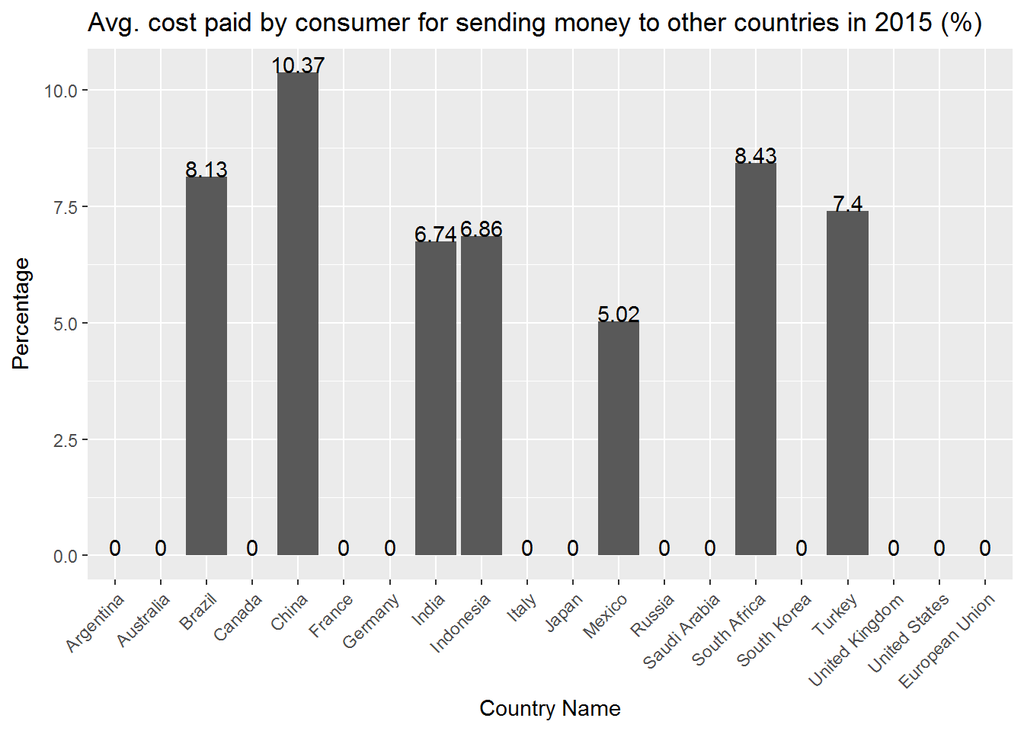

```r
# Displays Average transaction cost of sending remittances from a specific country (%) in 2015

ggplot(data=remit.to.from, aes(x=`Country.Name`, y=Sending)) + geom_bar(width=.9,stat="identity",position = "dodge") + theme(axis.text.x = element_text(angle = 45, hjust = 1)) + labs(x="Country Name", y="Percentage", title = "Avg. cost paid by consumer for sending money to other countries in 2015 (%)") + geom_text(aes(label=Sending), vjust=0, color="black")
```

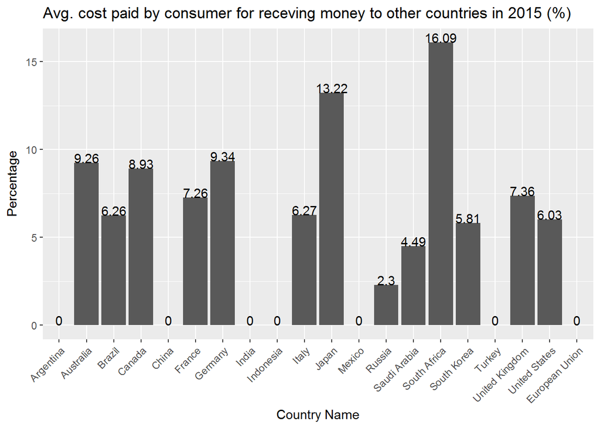

```r
# Displays Average transaction cost of receving remittances from a specific country (%) in 2015

ggplot(data=remit.to.from, aes(x=`Country.Name`, y=Receving)) + geom_bar(width=.9,stat="identity",position = "dodge") + theme(axis.text.x = element_text(angle = 45, hjust = 1)) + labs(x="Country Name", y="Percentage", title = "Avg. cost paid by consumer for receving money to other countries in 2015 (%)") + geom_text(aes(label=Receving), vjust=0, color="black")
```

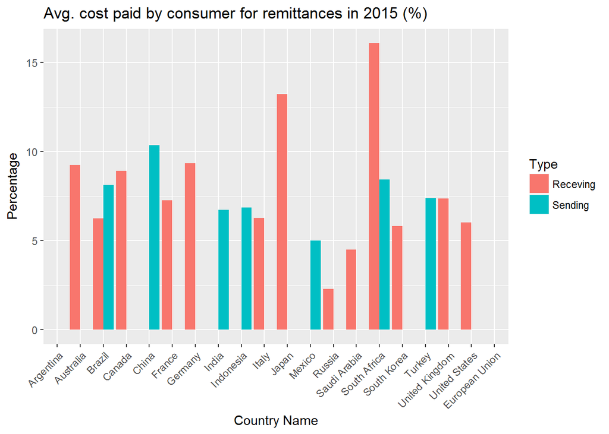

```r
# Tidy the data and get countries that charge consumers for sending and receving remittances
remit.to.from.charge <- remit.to.from %>%
  #filter(Sending>0 & Receving >0) %>%
  select (`Country.Name`,Sending,Receving) %>%
  gather(Type, value = Measure, -Country.Name,  na.rm = FALSE)

ggplot(remit.to.from.charge, aes(x = Country.Name,y = Measure)) +
geom_bar(aes(fill = Type), position = "dodge", stat="identity") + theme(axis.text.x = element_text(angle = 45, hjust = 1)) + labs(x="Country Name", y="Percentage", title = "Avg. cost paid by consumer for remittances in 2015 (%)")
```

### 2. IRS’s Statistics of Income (SOI)

Internal Revenue Service (IRS) maintains [*Statistics of Income (SOI) - County Data.*](https://www.irs.gov/uac/soi-tax-stats-county-data) SOI bases its county income data on the addresses reported on individual income tax returns filed with the IRS. Database includes:

- Number of returns, which approximates the number of households
- Number of personal exemptions, which approximates the population
- Adjusted gross income
- Wages and salaries
- Dividends before exclusion
- Interest received

More information about data classification and collection can be found at

1. Data information: https://www.irs.gov/uac/soi-tax-stats-county-data
2. Data collection and processing: https://www.irs.gov/uac/soi-tax-stats-purpose-and-function-of-statistics-of-income-soi-program
3. Data Dictionary and Users Guide: https://www.irs.gov/uac/soi-tax-stats-county-income-data-users-guide-and-record-layouts

Using SOI Tax Stats - County Database 2014, metrics for California and Texas will be analysed. For the scope of the project returns will be analysis based on *Adjusted gross income* and *Filing status* for both states.

```r
wd <- getwd()
# Data Dictionary
soi.data.dic <- read.xlsx2(paste(wd, "\\SOI_Data_Dictionary_County2014.xlsx", sep = ""), sheetName = "Sheet1", startRow=2, endRow = 138, startColumn = 1, endColumn = 6, as.data.frame = T, header = T, colClasses = "character", stringsAsFactors = FALSE)

# Get agi range
agi_range <- soi.data.dic %>%
  filter(TYPE == "") %>%
  select (VALUE.LINE.REFERENCE) %>%
  separate(VALUE.LINE.REFERENCE, c("agi_id","agi_desc"), sep = "\\s=\\s")

agi_range$agi_id <- as.numeric(as.character(agi_range$agi_id))

# Load Statistics of Income (SOI) - County Data from 14incyallagi.csv
# This file contains county level tax filing details and also has state level rollup
# There are about 25536 observations and 128 variables that covers all states
# California (CA) and Texas (TX) states data will be used for this project

soi.raw.data <- read.csv(paste(wd , "\\14incyallagi.csv", sep = ""), stringsAsFactors = FALSE, header = TRUE)

# agi_stub = Adjusted gross income (1-Under $1, 2-$1 under $10,000, 3-$10,000 under $25,000,4-$25,000 under $50,000,5-$50,000 under $75,000,6-$75,000 under $100,000,7-$100,000 under $200,000,8-$200,000 or more
# numberOfTIReturns = Number of returns with taxable income
# tIAmount = Taxable income amount
# numberOfTPReturns = Number of returns with total tax payments
# tPAmount = Total tax payments amount

# Tidy the data and get required data
# Missing values, since numberOfSingleReturns + numberOfJointReturns + numberOfHOHReturns != numberOfReturns
# add otherReturns
soi.ca.tx.data <- soi.raw.data %>%
  filter(STATE %in% c("CA","TX") & COUNTYFIPS == 0) %>%
  mutate(otherReturns = (N1 - (mars1+MARS2+MARS4))) %>%
  select(agi_stub,state = COUNTYNAME, numberOfReturns = N1, numberOfSingleReturns = mars1, numberOfJointReturns = MARS2, numberOfHOHReturns = MARS4, otherReturns, numberOfTIReturns = N04800, tIAmount = A04800, numberOfTPReturns = N10600, tPAmount = A10600) %>%
  inner_join(agi_range, by = c("agi_stub" = "agi_id"))

# Calculate percentages
soi.ca.tx.data %<>%
  group_by(state) %>%
  summarise(totalReturns = sum(numberOfReturns)) %>%
  select (state,totalReturns) %>%
  inner_join(soi.ca.tx.data, by = "state")

soi.ca.tx.data <- mutate(soi.ca.tx.data, "SingleReturns" = round(numberOfSingleReturns*100/totalReturns,2))
soi.ca.tx.data <- mutate(soi.ca.tx.data, "JointReturns" = round(numberOfJointReturns*100/totalReturns,2))
soi.ca.tx.data <- mutate(soi.ca.tx.data, "HOHReturns" = round(numberOfHOHReturns*100/totalReturns,2))
soi.ca.tx.data <- mutate(soi.ca.tx.data, "OtherReturns" = round(otherReturns*100/totalReturns,2))
soi.ca.tx.data <- mutate(soi.ca.tx.data, "Total" = SingleReturns+JointReturns+HOHReturns+OtherReturns)

# Generate report to compare percentage of tax returns files
soi.ca.tx.data %>%
  select (state, agi_stub, agi_desc, Total) %>%
  arrange(agi_stub) %>%
  spread(state, Total) %>%
  select (agi_desc, California, Texas) %>%
  kable(digits = 2, col.names = c("Adjusted Gross Income", "California(%)", "Texas(%)"), format='pandoc', caption = "Percentage of Tax Returns filed based on Adjusted Gross Income for year 2014")
```

Percentage of Tax Returns filed based on Adjusted Gross Income for year 2014

| Adjusted Gross Income | California(%) | Texas(%) |
| --- | --- | --- |
| Under $1 | 1.70 | 1.24 |
| $1 under $10,000 | 13.50 | 14.46 |
| $10,000 under $25,000 | 22.90 | 24.06 |
| $25,000 under $50,000 | 22.78 | 23.93 |
| $50,000 under $75,000 | 12.67 | 12.69 |
| $75,000 under $100,000 | 8.11 | 7.93 |
| $100,000 under $200,000 | 12.71 | 11.28 |
| $200,000 or more | 5.63 | 4.42 |

Graphical representation.

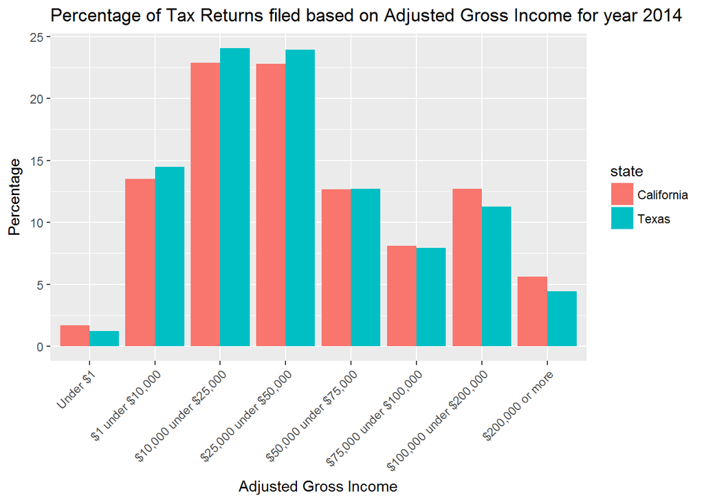

```r
# Rearrange the data
soi.ca.tx.data <- arrange(soi.ca.tx.data, agi_stub, agi_desc)
soi.ca.tx.data <- transform(soi.ca.tx.data, agi_desc=factor(agi_desc,levels=unique(agi_desc)))

# Generate graph to compare taxes returns files based on Adjusted Gross Income
ggplot(soi.ca.tx.data, aes(x = agi_desc,y = Total)) +
geom_bar(aes(fill = state), position = "dodge", stat="identity") + theme(axis.text.x = element_text(angle = 45, hjust = 1)) + labs(x="Adjusted Gross Income", y="Percentage", title = "Percentage of Tax Returns filed based on Adjusted Gross Income for year 2014")
```

```r
# Generate report based on filing status
ca.tx.c1 <- soi.ca.tx.data %>%
  group_by(state) %>%
  summarise(Single = sum(SingleReturns), Joint = sum(JointReturns), "Head Of Household" = sum(HOHReturns), Other=sum(OtherReturns)) %>%
  select (state, Single, Joint, `Head Of Household`, Other) %>%
  gather(ReturnType, "n", Single, Joint, `Head Of Household`, Other) %>%
  select(state, ReturnType, Total=n) %>%
  spread(state, Total)

# Arrange data
ca.tx.c1 <- arrange(ca.tx.c1, desc(California))
ca.tx.c1 <- mutate(ca.tx.c1, id = row_number())
ca.tx.c1 <- transform(ca.tx.c1, id=factor(id,levels=unique(id)))
ca.tx.c1 %>%
  select(ReturnType, California, Texas) %>%
kable(digits = 2, col.names = c("Return Type", "California(%)", "Texas(%)"), format='pandoc', caption = "Percentage of Tax Returns filed based on Status for year 2014")
```

Percentage of Tax Returns filed based on Status for year 2014

| Return Type | California(%) | Texas(%) |
| --- | --- | --- |
| Single | 47.93 | 44.51 |
| Joint | 35.85 | 36.83 |
| Head Of Household | 14.85 | 17.27 |
| Other | 1.37 | 1.40 |

Graphical representation.

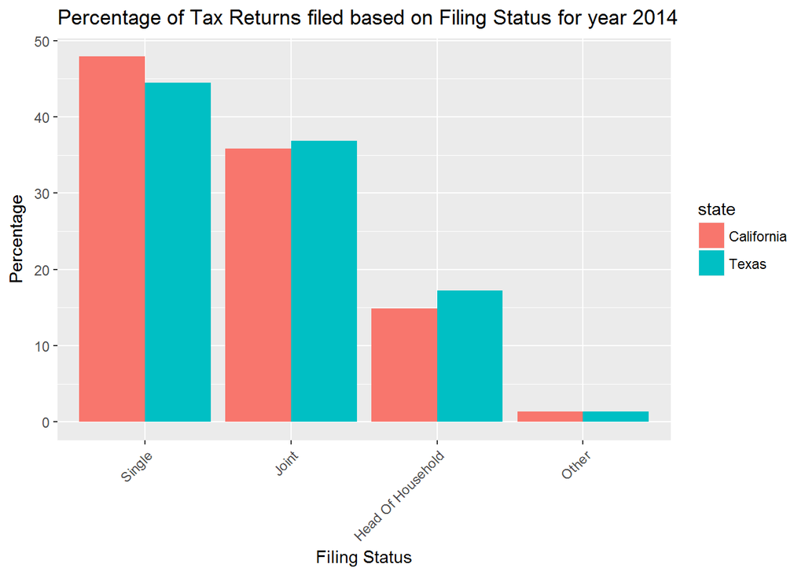

```r
# Get the dataset
ca.tx.c2 <-
soi.ca.tx.data %>%
  group_by(state) %>%
  summarise(Single = sum(SingleReturns), Joint = sum(JointReturns), "Head Of Household" = sum(HOHReturns), Other=sum(OtherReturns)) %>%
  select (state, Single, Joint, `Head Of Household`, Other) %>%
  gather(ReturnType, "n", Single, Joint, `Head Of Household`, Other) %>%
  select(state, ReturnType, Total=n)

# Returns filing order
filing <- c("Single","Joint","Head Of Household","Other")
id <- c(1,2,3,4)
filing.order <- data.frame(filing, id, stringsAsFactors = FALSE)

ca.tx.c2 <- ca.tx.c2 %>%
  inner_join(filing.order, by = c("ReturnType" = "filing"))

ca.tx.c2 <- arrange(ca.tx.c2, state, id)
ca.tx.c2 <- transform(ca.tx.c2, ReturnType=factor(ReturnType,levels=unique(ReturnType)))


# Generate graph to compare taxes returns files based on Adjusted Gross Income
ggplot(ca.tx.c2, aes(x = ReturnType,y = Total)) +
geom_bar(aes(fill = state), position = "dodge", stat="identity") + theme(axis.text.x = element_text(angle = 45, hjust = 1)) + labs(x="Filing Status", y="Percentage", title = "Percentage of Tax Returns filed based on Filing Status for year 2014")
```

Conclusion:

1. Texas has slightly more percentage of population that earns between $1 under $50,000.
2. California and Texas has approxmimately same percentage of population that earns between $50,000 under $75,000.
3. California has slightly more percentage of population that earns above $75,000.

### 3. United States Census Bureau - Imports of Crude Oil

The United States Census Bureau is a principal agency of the U.S. Federal Statistical System, responsible for producing data about the American people and economy. Statistics of [*U.S. Imports of Crude Oil*](https://www.census.gov/foreign-trade/statistics/historical/index.html) is compiled with the help of U.S. Customs and Border Protection and the Bureau of Economic Analysis. Purpose of this database is to provide detailed statistics on goods and estimates of services entering the U.S. from foreign countries.

More information about data and program can be found at

1. Program details: https://www.census.gov/foreign-trade/about/index.html
2. Foreign Trade historical data: https://www.census.gov/foreign-trade/statistics/historical/index.html
3. U.S. Imports of Crude Oil: https://www.census.gov/foreign-trade/statistics/historical/petr.txt

Using the U.S. Imports of Crude Oil database, metrics for yearly imports of crude oil and costs will be analysed. Since years 2017 and 2018 does not have complete data, years will not be used for analysis.

```r
# Get local directory and load the file
localDir <- getwd()

# Skip top 24 lines as it contains header info
crude.oil.text <- read_lines(paste(str_trim(localDir),"//petr.txt",sep=""),skip = 24)

# Remove Spaces and replace with pipe(|)
pattern = "\\s+"
replacement = "|"
crude.oil.text <- gsub(pattern = pattern, replacement = replacement, crude.oil.text)

# Remove unnecessary data
pattern = "Jan\\."
crude.noneed.data <- crude.oil.text[str_detect(crude.oil.text, pattern = pattern)]
crude.oil.text <- crude.oil.text [! crude.oil.text %in% crude.noneed.data]

# Create data frame and add id column
# Split the data into 15 columns
crude.oil.data <- data.frame(unlist(str_split_fixed(crude.oil.text, "\\|", 15)), stringsAsFactors = F)
crude.oil.data <- mutate(crude.oil.data, id = row_number())

# Since data is text format and yearly data is stored side-by-side, convert it to single table
# File has about 46 yearly data sets, 2017 and 2018 data set is not used for analysis
start = 1
end = 13
crude.oil.tidy.data <- crude.oil.data %>%
    filter(id == 0) %>%
    select(X2:X8)

for (i in 1:22)
{
  # Get first set
  temp1 <- crude.oil.data %>%
    filter(id >= start & id <= end) %>%
    select(id, X1:X8)

  year <- crude.oil.data %>%
    filter (id == start) %>%
    select(X2)

  # Get year
  temp1$X1[temp1$X1 == ""] <- year

  # Get second set of data which is same side-by-side
  temp2 <- crude.oil.data %>%
    filter(id >= start & id <= end) %>%
    select(id, X1, X2=X9, X3=X10, X4=X11, X5=X12, X6=X13, X7=X14, X8=X15)

  # Get year
  year <- crude.oil.data %>%
    filter (id == start) %>%
    select(X3)

  temp2$X1[temp2$X1 == ""] <- year

  # Remove extra rows from temp data frames
  temp1 <- temp1[-c(1), ]
  temp2 <- temp2[-c(1), ]

  # Store data into tidy table
  crude.oil.tidy.data <- bind_rows(crude.oil.tidy.data,temp1)
  crude.oil.tidy.data <- bind_rows(crude.oil.tidy.data,temp2)

  start = end + 1
  end = end + 13
}

# Add new id column and remove un-used columns
crude.oil.tidy.data$X1 <- as.numeric(unlist(crude.oil.tidy.data$X1))
crude.oil.tidy.data <- arrange(crude.oil.tidy.data, X1,id) %>% mutate(seq = row_number())
crude.oil.tidy.data$id <- NULL
crude.oil.tidy.data$X4 <- NULL
crude.oil.tidy.data$X6 <- NULL
crude.oil.tidy.data$X7 <- NULL
crude.oil.tidy.data$X8 <- NULL

# Format data and replace missing values with zeros
crude.oil.tidy.data$X3 <- as.numeric(ifelse(crude.oil.tidy.data$X3 == "N/A", "0",str_replace_all(crude.oil.tidy.data$X3,",","")))

crude.oil.tidy.data$X5 <- as.numeric(ifelse(crude.oil.tidy.data$X5 == "N/A", "0",str_replace_all(crude.oil.tidy.data$X5,",","")))

crude.oil.tidy.data <-  rename(crude.oil.tidy.data, Month = X2, Barrels = X3, Value = X5, Year = X1)

# Summarise data
crude.oil.yearly.data <- crude.oil.tidy.data %>%
  group_by(Year) %>%
  summarise(TotalBarrels = round(sum(Barrels)/10000,2), TotalValue = round(sum(Value)/10000,2), AverageBarrels = round(mean(Barrels)/10000,2), AverageValue = round(mean(Value)/10000,2))

# Generate report
crude.oil.yearly.data %>%
  select (Year, AverageBarrels) %>%
kable(digits = 2, col.names = c("Year", "Quantity (10 thousands of Barrels)"), format='pandoc', caption = "U.S. Yearly Average Imports of Crude Oil 1973 - 2016")
```

U.S. Yearly Average Imports of Crude Oil 1973 - 2016

| Year | Quantity (10 thousands of Barrels) |
| --- | --- |
| 1973 | 11.61 |
| 1974 | 12.20 |
| 1975 | 13.21 |
| 1976 | 17.09 |
| 1977 | 21.00 |
| 1978 | 19.94 |
| 1979 | 20.56 |
| 1980 | 16.48 |
| 1981 | 14.69 |
| 1982 | 11.84 |
| 1983 | 10.78 |
| 1984 | 11.00 |
| 1985 | 10.51 |
| 1986 | 13.62 |
| 1987 | 14.54 |
| 1988 | 15.73 |
| 1989 | 17.89 |
| 1990 | 18.47 |
| 1991 | 17.88 |
| 1992 | 19.12 |
| 1993 | 21.19 |
| 1994 | 22.53 |
| 1995 | 23.06 |
| 1996 | 24.11 |
| 1997 | 25.58 |
| 1998 | 27.02 |
| 1999 | 26.90 |
| 2000 | 28.33 |
| 2001 | 28.93 |
| 2002 | 28.48 |
| 2003 | 30.63 |
| 2004 | 31.84 |
| 2005 | 31.29 |
| 2006 | 31.12 |
| 2007 | 30.75 |
| 2008 | 29.92 |
| 2009 | 27.62 |
| 2010 | 28.14 |
| 2011 | 27.68 |
| 2012 | 25.81 |
| 2013 | 23.45 |
| 2014 | 22.51 |
| 2015 | 22.18 |
| 2016 | 23.39 |

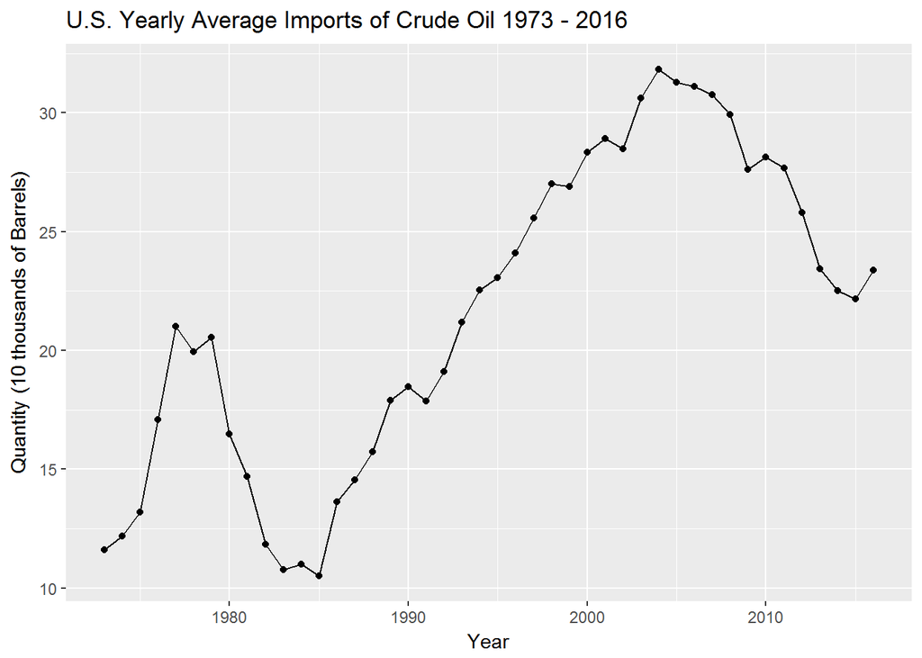

```r
# Graphical representation
ggplot(data=crude.oil.yearly.data, aes(x=Year, y=AverageBarrels, group=1)) +
    geom_line() +
    geom_point() + labs(x="Year", y="Quantity (10 thousands of Barrels)", title = "U.S. Yearly Average Imports of Crude Oil 1973 - 2016")
```

```r
crude.oil.yearly.data %>%
  select (Year, AverageValue) %>%
kable(digits = 2, col.names = c("Year", "Value (10 thousands of Dollars)"), format='pandoc', caption = "U.S. Yearly Average Imports of Crude Oil 1973 - 2016")
```

U.S. Yearly Average Imports of Crude Oil 1973 - 2016

| Year | Value (10 thousands of Dollars) |
| --- | --- |
| 1973 | 38.27 |
| 1974 | 137.35 |
| 1975 | 153.12 |
| 1976 | 212.33 |
| 1977 | 279.85 |
| 1978 | 267.84 |
| 1979 | 384.17 |
| 1980 | 516.79 |
| 1981 | 516.17 |
| 1982 | 395.38 |
| 1983 | 318.20 |
| 1984 | 304.41 |
| 1985 | 275.29 |
| 1986 | 189.34 |
| 1987 | 244.34 |
| 1988 | 223.70 |
| 1989 | 295.00 |
| 1990 | 364.87 |
| 1991 | 312.20 |
| 1992 | 321.28 |
| 1993 | 320.58 |
| 1994 | 320.66 |
| 1995 | 364.58 |
| 1996 | 457.76 |
| 1997 | 451.88 |
| 1998 | 310.44 |
| 1999 | 424.08 |
| 2000 | 748.97 |
| 2001 | 619.11 |
| 2002 | 644.03 |
| 2003 | 826.39 |
| 2004 | 1097.86 |
| 2005 | 1464.63 |
| 2006 | 1805.23 |
| 2007 | 1976.76 |
| 2008 | 2849.27 |
| 2009 | 1572.60 |
| 2010 | 2101.34 |
| 2011 | 2763.18 |
| 2012 | 2609.79 |
| 2013 | 2273.39 |
| 2014 | 2053.40 |
| 2015 | 1048.48 |
| 2016 | 844.10 |

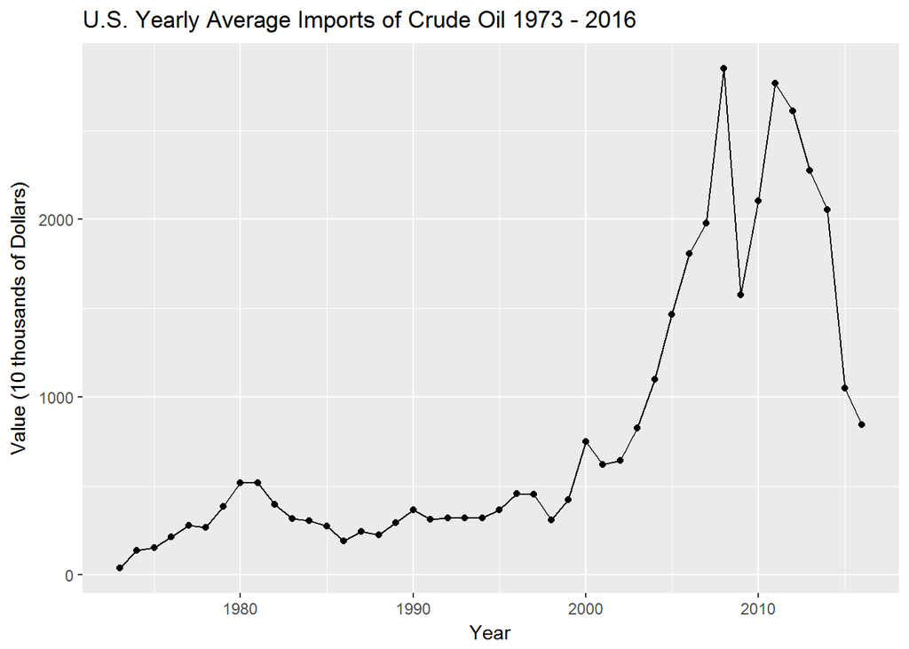

```r
# Graphical representation
ggplot(data=crude.oil.yearly.data, aes(x=Year, y=AverageValue, group=1)) +
    geom_line() +
    geom_point() + labs(x="Year", y="Value (10 thousands of Dollars)", title = "U.S. Yearly Average Imports of Crude Oil 1973 - 2016")
```

```r
# Generate data for seasons
seasons <- c("Winter", "Winter", "Winter", "Spring", "Spring", "Spring", "Summer", "Summer", "Summer", "Fall", "Fall", "Fall")
m <- c("December", "January", "February", "March","April", "May", "June", "July", "August", "September", "October", "November")
id <- c(4,4,4,1,1,1,2,2,2,3,3,3)

seasons.data <- data.frame(seasons, m, id)
seasons.data$seasons <- as.character(seasons.data$seasons)
seasons.data$m <- as.character(seasons.data$m)

crude.oil.season.data <- crude.oil.tidy.data %>%
  filter(Year >= 2007) %>%
  inner_join(seasons.data, c("Month" = "m")) %>%
  group_by(Year,seasons,id) %>%
  summarise(TotalBarrels = round(sum(Barrels)/10000,2), TotalValue = round(sum(Value)/10000,2), AverageBarrels = round(mean(Barrels)/10000,2), AverageValue = round(mean(Value)/10000,2))

# Rearrange the data
crude.oil.season.data <- arrange(crude.oil.season.data, Year, id, seasons)
crude.oil.season.data <- transform(crude.oil.season.data, seasons=factor(seasons,levels=unique(seasons)))

crude.oil.season.data %>%
  arrange(Year, id) %>%
  select (Year, seasons, TotalBarrels) %>%
kable(digits = 2, col.names = c("Year", "Season", "Quantity (10 thousands of Dollars)"), format='pandoc', caption = "U.S. Imports of Crude Oil per Season 2007 - 2016")
```

U.S. Imports of Crude Oil per Season 2007 - 2016

[output not shown]

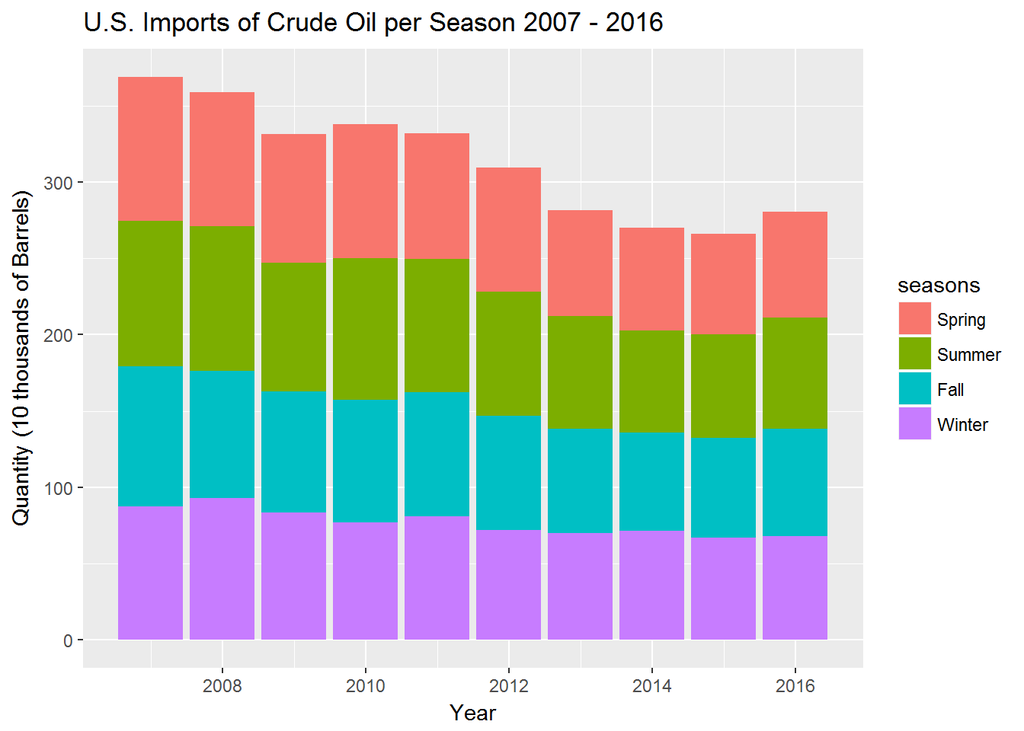

```r
ggplot(data=crude.oil.season.data, aes(x=Year, y=TotalBarrels, fill=seasons)) +
    geom_bar(stat="identity") + labs(x="Year", y="Quantity (10 thousands of Barrels)", title = "U.S. Imports of Crude Oil per Season 2007 - 2016")
```

```r
crude.oil.season.data %>%
  arrange(Year, id) %>%
  select (Year, seasons, TotalValue) %>%
kable(digits = 2, col.names = c("Year", "Season", "Value (10 thousands of Dollars)"), format='pandoc', caption = "U.S. Imports of Crude Oil per Season 2007 - 2016")
```

U.S. Imports of Crude Oil per Season 2007 - 2016

| Year | Season | Value (10 thousands of Dollars) |
| --- | --- | --- |
| 2007 | Spring | 5358.51 |
| 2007 | Summer | 6163.29 |
| 2007 | Fall | 6756.07 |
| 2007 | Winter | 5443.30 |
| 2008 | Spring | 8594.62 |
| 2008 | Summer | 11492.08 |
| 2008 | Fall | 7379.61 |
| 2008 | Winter | 6724.93 |
| 2009 | Spring | 3902.07 |
| 2009 | Summer | 5253.04 |
| 2009 | Fall | 5476.85 |
| 2009 | Winter | 4239.22 |
| 2010 | Spring | 6658.94 |
| 2010 | Summer | 6744.47 |
| 2010 | Fall | 5968.91 |
| 2010 | Winter | 5843.73 |
| 2011 | Spring | 8376.87 |
| 2011 | Summer | 9151.45 |
| 2011 | Fall | 8157.05 |
| 2011 | Winter | 7472.83 |
| 2012 | Spring | 8838.33 |
| 2012 | Summer | 7824.15 |
| 2012 | Fall | 7395.09 |
| 2012 | Winter | 7259.93 |
| 2013 | Spring | 6727.45 |
| 2013 | Summer | 7236.61 |
| 2013 | Fall | 6779.38 |
| 2013 | Winter | 6537.28 |
| 2014 | Spring | 6432.45 |
| 2014 | Summer | 6476.85 |
| 2014 | Fall | 5652.31 |
| 2014 | Winter | 6079.17 |
| 2015 | Spring | 3156.12 |
| 2015 | Summer | 3565.80 |
| 2015 | Fall | 2651.97 |
| 2015 | Winter | 3207.90 |
| 2016 | Spring | 2115.18 |
| 2016 | Summer | 2899.84 |
| 2016 | Fall | 2809.48 |
| 2016 | Winter | 2304.68 |

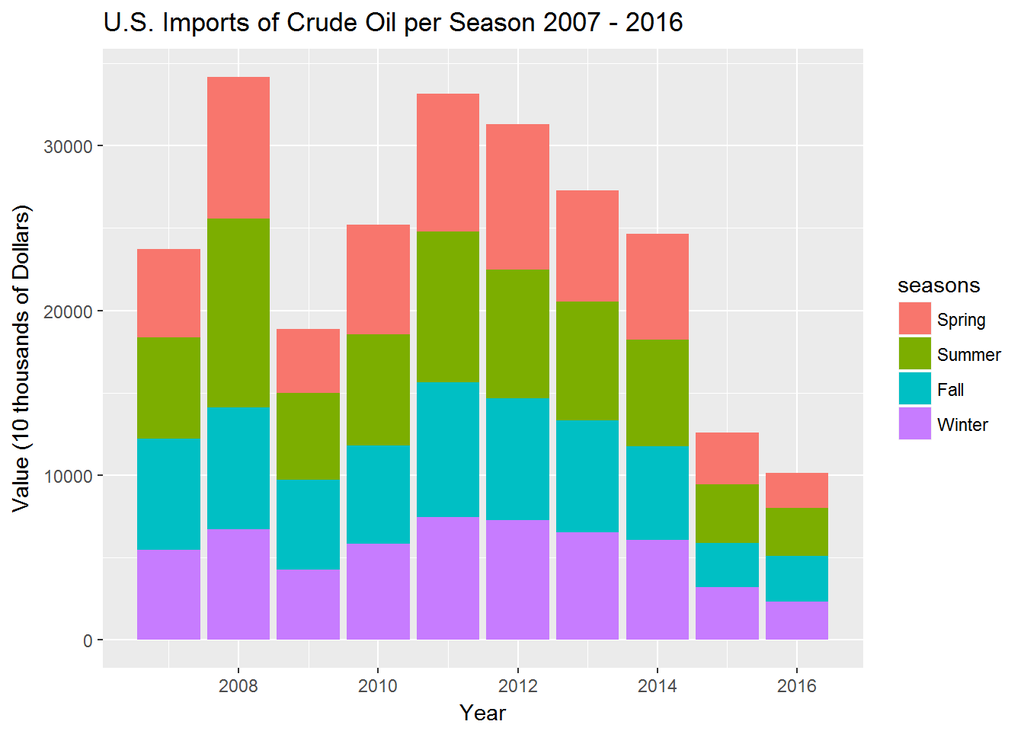

```r
ggplot(data=crude.oil.season.data, aes(x=Year, y=TotalValue, fill=seasons)) +
    geom_bar(stat="identity") + labs(x="Year", y="Value (10 thousands of Dollars)", title = "U.S. Imports of Crude Oil per Season 2007 - 2016")
```

References: https://cran.rstudio.com/web/packages/dplyr/vignettes/introduction.html https://github.com/rstudio/webinars/tree/master/05-Data-Wrangling-with-R-and-RStudio https://www.r-bloggers.com/importexport-data-to-and-from-xlsx-files/

<sup>1</sup>: For the course of this project words dataset and database are interchangeable.